# Summer Project Report 1

Tumor Data EDA

Aditya Jalin

# Gene Expression

## Data Overview

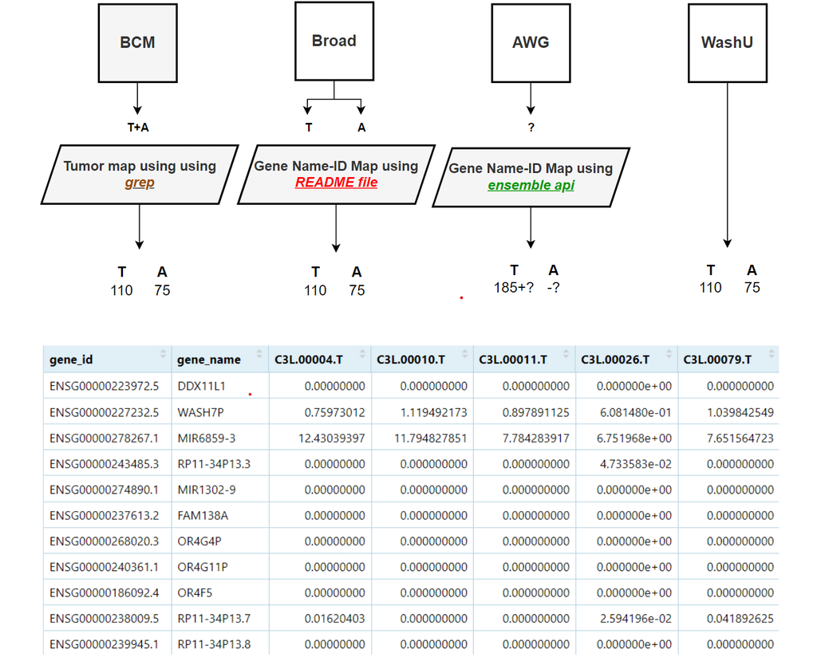

[output not shown]

```
## [1] 111
```

```
## logical(0)
```

```
## [1] 75
```

```r
#Gene_Broad <- read_parquet(paste(data_path,'/Gene_expression/Gene_expression/ccRCC/Broad/CCRCC.gene_tpm.parquet',sep=""))

#Gene Map For Broad
broad_id_map<- read.delim(paste(data_path,"/Gene_expression/Gene_expression/README/Broad/sample_descriptions.tsv",sep=""))
broad_id_c <- broad_id_map[broad_id_map$cohort=="CCRCC",]

# Create a new dataframe with column names replaced
Gene_Broad_new <- Gene_Broad
colnames(Gene_Broad_new)[-c(1, length(colnames(Gene_Broad_new)))] <- broad_id_c$GDC_id[match(colnames(Gene_Broad)[-c(1, length(colnames(Gene_Broad_new)))], broad_id_c$sample_id)]


# Split dataframe based on tissue_type
Gene_Broad_Tumor <- Gene_Broad_new[, c("Name",broad_id_c$GDC_id[ broad_id_c$tissue_type == "Tumor"])]
colnames(Gene_Broad_Tumor)[1] <- "id"

Gene_Broad_Normal <- Gene_Broad_new[, c("Name",broad_id_c$GDC_id[ broad_id_c$tissue_type == "Normal"])]
```

```r
# Wash-U data
#Gene_WashU_Tumor <- read.delim(paste(data_path,'/Gene_expression/Gene_expression/ccRCC/WashU/ccRCC_tumor_RNA-Seq_Expr_WashU_FPKM.tsv.gz',sep=""))
#Gene_WashU_Normal <- read.delim(paste(data_path,'/Gene_expression/Gene_expression/ccRCC/WashU/ccRCC_NAT_RNA-Seq_Expr_WashU_FPKM.tsv.gz',sep=""))
Gene_WashU_Tumor<-Gene_WashU_Tumor[,-2]
colnames(Gene_WashU_Tumor)[1] <- "id"


#Gene_AWG_Tumor <- read.delim(paste(data_path,'/Gene_expression/Gene_expression/ccRCC/AWG_data_freeze/RNA_rpkm_tumor_normal.tsv',sep=""))

Genes_c <- getBM(attributes = c("ensembl_gene_id","external_gene_name"),
                    filters = "external_gene_name",
                    values = Gene_AWG_Tumor$geneID,
                    mart = ensembl)
genes_c <- subset(Genes_c,!duplicated(external_gene_name))
Gene_AWG_Tumor <- merge(genes_c,Gene_AWG_Tumor,by.x="external_gene_name",by.y="geneID",all=TRUE)
Gene_AWG_Tumor <- Gene_AWG_Tumor[,-1]
colnames(Gene_AWG_Tumor)[1] <- "id"
```

## Exploration

- AWG Freeze data is unlabelled
- Using the exact ensemble version leads to depreciation in number of proteins
- Even after removing the version, some genes still aren’t present in the ensemble api call

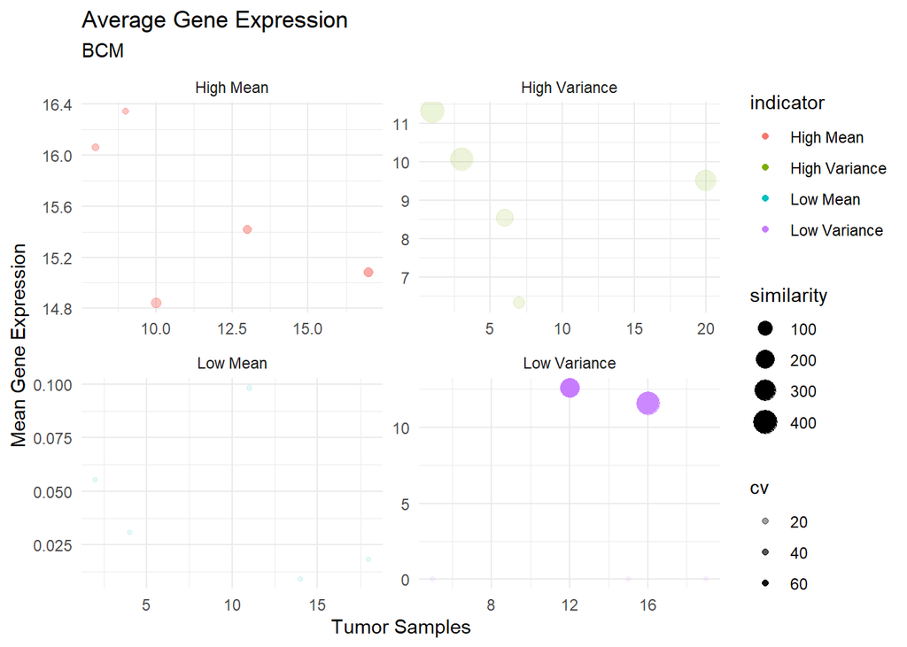

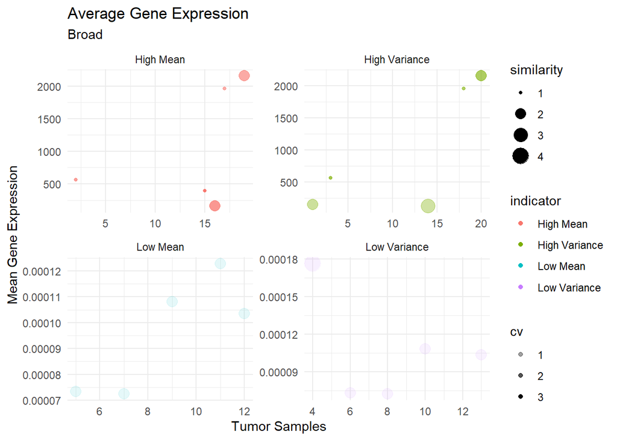

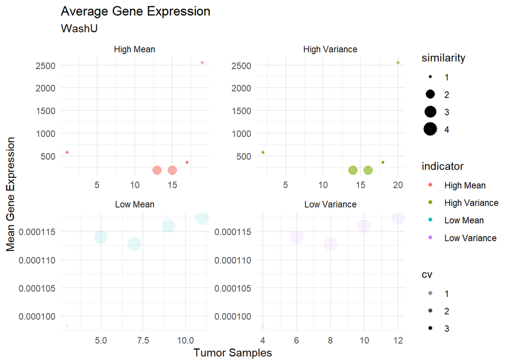

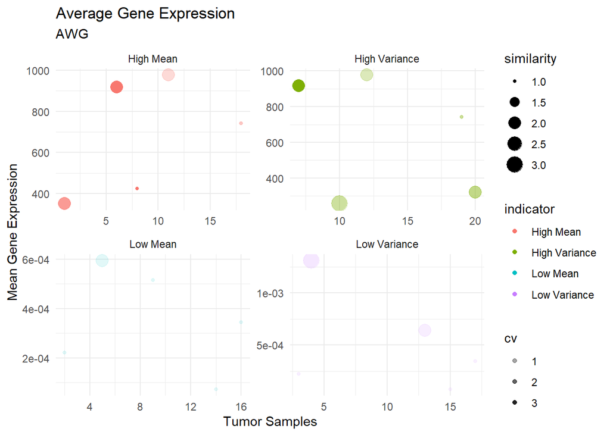

Having trouble reading the methylation data due to size

```r
#Meth <- fread(paste(data_path,"/DNA_methylation/DNA_methylation/ALL/WashU/CCRCC_allPatients.081621.csv.gz",sep = ""), nrows  = 100)

Meth_info <- Meth[,1:2]

Meth_info <- Meth_info %>%
  mutate(
    chromosome = as.numeric(stringr::str_extract(index, "(?<=chr)\\d+(?=:)")),
    start_pos = as.numeric(stringr::str_extract(index, "(?<=:)\\d+")),
    end_pos = as.numeric(stringr::str_extract(index, "(?<=-)\\d+"))
  )

Genes <- Gene_BCM_Tumor$id
Genes <- Gene_Broad_Tumor$id
Genes <- Gene_WashU_Tumor$id
Genes <- Gene_AWG_Tumor$id


genes <- sub("\\..*", "", Genes)


#Taking only the names and not version

attributes_d <- c("ensembl_gene_id","ensembl_gene_id_version",
                "external_gene_name",
                "start_position",
                "end_position","chromosome_name")
gene_mapping2 <- getBM(attributes = attributes_d,
                      filters = "ensembl_gene_id",
                      values = genes,
                      mart = ensembl)
length(which(!genes %in% gene_mapping2$ensembl_gene_id))
```

```
## [1] 932
```

```r
# Assuming you have a variable named 'Meth' containing the methylation data

# Step 1: Create an empty vector to store the genes with methylation
genes_with_methylation <- character()

# Step 2: Iterate over each gene and check for methylation
for (i in seq(1:dim(gene_mapping2)[1])) {
  gene_start <- gene_mapping2$start_position[i]
  gene_end <- gene_mapping2$end_position[i]

  # Check if any methylation values fall within the gene's start and end positions
  if (any(Meth_info$start_pos >= gene_start & Meth_info$end_pos <= gene_end)) {
    genes_with_methylation <- c(genes_with_methylation, gene_mapping2$ensembl_gene_id[i])
  }
}

# Step 1: Create an empty dataframe with gene IDs as rows
gene_data <- data.frame(gene_id = gene_mapping2$ensembl_gene_id, stringsAsFactors = FALSE)

# Step 2: Add columns from the Meth dataframe to the gene_data dataframe
gene_data$Methylation <- gene_data$gene_id %in% genes_with_methylation
sum(gene_data$Methylation)
```

```
## [1] 632
```

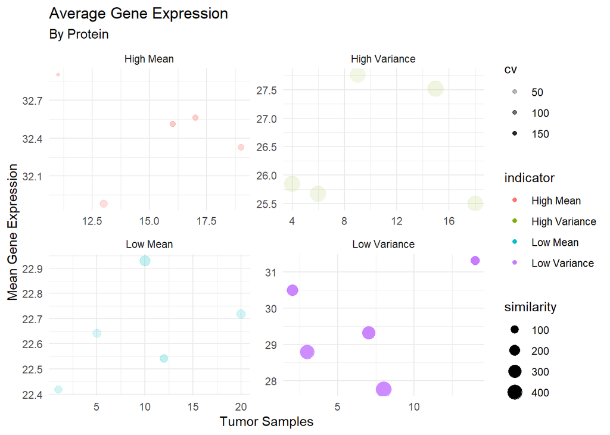

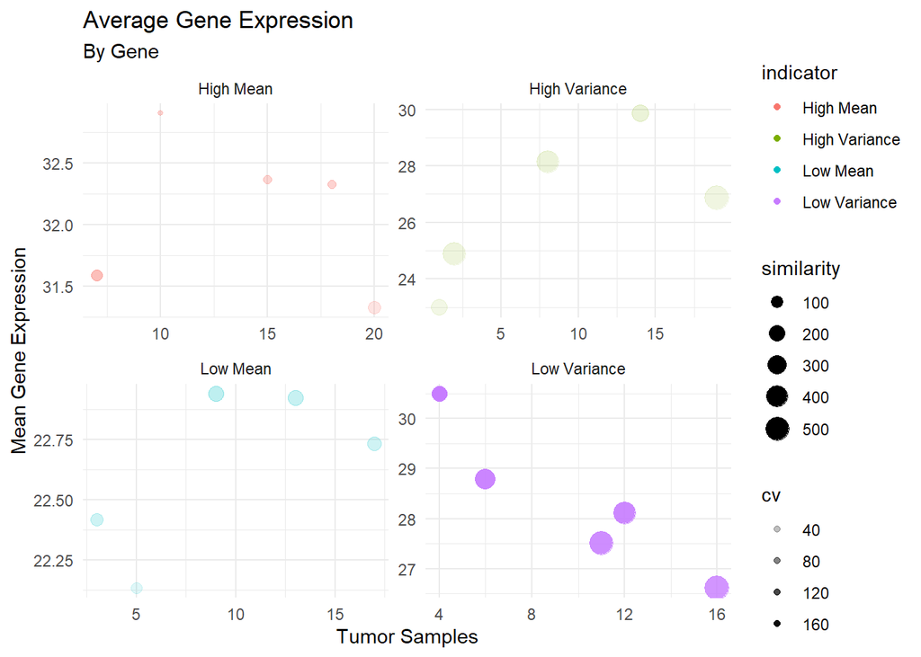

```r
#all_data_by_genes <- read.delim(paste(
#                          data_path, #"/Somatic_cnv/Somatic_cnv/ALL/Broad_pipeline_wxs/all_data_by_genes.txt",sep=""))


c<-gene_mapping2$external_gene_name
d <- all_data_by_genes$Gene.Symbol


e<-sapply(d, function(x) strsplit(x, "|", fixed = TRUE)[[1]][1])
sum((!e %in% c))

a<-all_data_by_genes[1,3:length(all_data_by_genes)]
b<-unlist((a[1,2:length(a)]/length(a)))

library(dplyr)

result <- all_data_by_genes[1:1000,-c(2,3)] %>%
  mutate(mean_value = rowMeans(across(-Gene.Symbol))) %>%
  mutate(variance = apply(.[,-1], 1, var)) %>%
  mutate(indicator = case_when(
    rank(variance, ties.method ="first") <= 5 ~ "High Variance",
    rank(variance, ties.method = "first") >= (nrow(.) - 4) ~ "Low Variance",
    rank(mean_value, ties.method = "first") <= 5 ~ "High Mean",
    rank(mean_value, ties.method = "first") >= (nrow(.) - 4) ~ "Low Mean"
  )) %>%
  filter(indicator %in% c("High Mean", "Low Mean")|indicator %in% c("High Variance", "Low Variance"))%>%
  dplyr::select(c(Gene.Symbol,mean_value,variance,indicator))

rank(result$mean_value,ties.method = "first")
rank(result$variance,ties.method = "first")

result
```

[output not shown]

# Overplotting

### Exercise 1

A data set doesn’t need thousands of observations to have overplotting. Consider a simple example using the `mpg` data set from `library(ggplot2)`.

Step 1: Create this plot using the `mpg` data set with variables `cyl` and `hwy`.

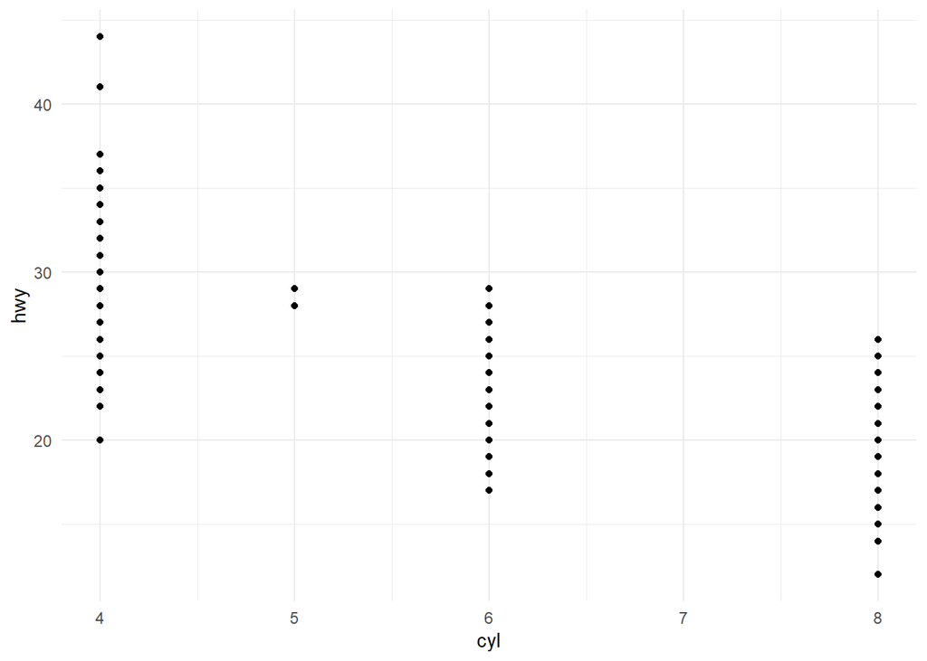

Step 2: Use `nrow(mpg)` to count the number of observations in `mpg`. Is there overplotting?

Step 3: Replace `geom_point()` with `geom_jitter()`. What happens?

Step 4: Experiment with the `width` and `height` arguments. You can see the documentation with `?geom_jitter`. What seems to be the best “best” combination?

The first pillar in The Seven Pillars of Statistical Wisdon by Stephen Stigler identifies an interesting paradox:

> “By aggregating, you lose the identity of the individual, so you’re throwing away information, but you’re also gaining information of a different sort. No one wants to be reduced to a statistic, but by losing the identity of the individual, you are producing information about the group.”

`geom_jitter()` creates a similar paradox. Just like how we gain information by throwing out information with aggregation, we can gain clarity by introducing errors to our data with `geom_jitter()`.

### Exercise 2

Now we’ll focus on the `diamonds` data set from `library(ggplot2)`. It contains information about 53,940 diamonds.

```r
glimpse(diamonds)
```

```
## Rows: 53,940
## Columns: 10
## $ carat   <dbl> 0.23, 0.21, 0.23, 0.29, 0.31, 0.24, 0.24, 0.26, 0.22, 0.23, 0.…
## $ cut     <ord> Ideal, Premium, Good, Premium, Good, Very Good, Very Good, Ver…
## $ color   <ord> E, E, E, I, J, J, I, H, E, H, J, J, F, J, E, E, I, J, J, J, I,…
## $ clarity <ord> SI2, SI1, VS1, VS2, SI2, VVS2, VVS1, SI1, VS2, VS1, SI1, VS1, …
## $ depth   <dbl> 61.5, 59.8, 56.9, 62.4, 63.3, 62.8, 62.3, 61.9, 65.1, 59.4, 64…
## $ table   <dbl> 55, 61, 65, 58, 58, 57, 57, 55, 61, 61, 55, 56, 61, 54, 62, 58…
## $ price   <int> 326, 326, 327, 334, 335, 336, 336, 337, 337, 338, 339, 340, 34…
## $ x       <dbl> 3.95, 3.89, 4.05, 4.20, 4.34, 3.94, 3.95, 4.07, 3.87, 4.00, 4.…
## $ y       <dbl> 3.98, 3.84, 4.07, 4.23, 4.35, 3.96, 3.98, 4.11, 3.78, 4.05, 4.…
## $ z       <dbl> 2.43, 2.31, 2.31, 2.63, 2.75, 2.48, 2.47, 2.53, 2.49, 2.39, 2.…
```

Jittering helps with overplotting with modestly sized data sets. It is not helpful with larger data sets. Let’s look at the diamonds data set with jitter:

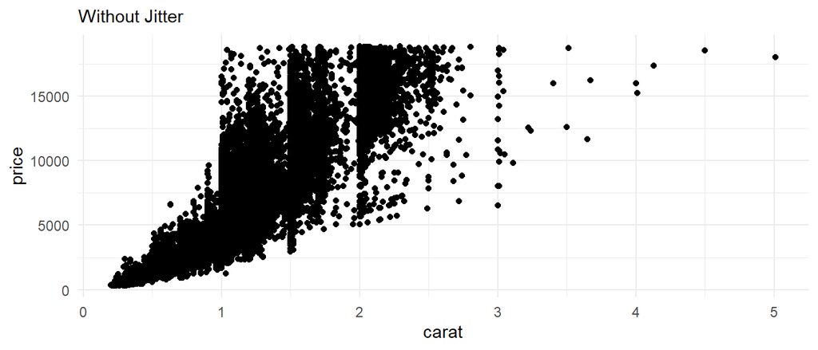

```r
without_jitter <- diamonds %>%
  ggplot(aes(x = carat, y = price)) +
  geom_point() +
  labs(subtitle = "Without Jitter")

with_jitter <- diamonds %>%
  ggplot(aes(x = carat, y = price)) +
  geom_jitter() +
  labs(subtitle = "With Jitter")
without_jitter
```

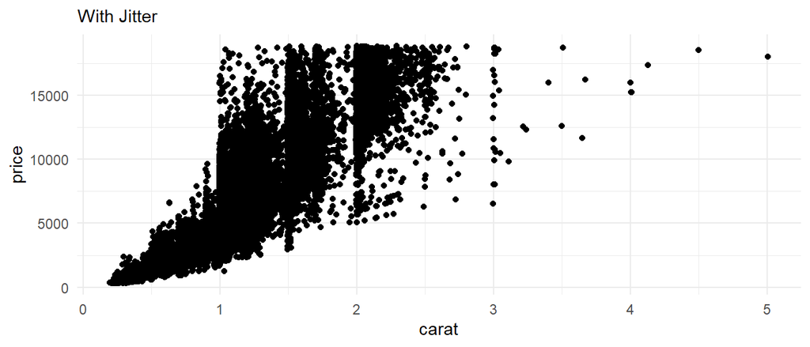

```r
with_jitter
```

Step 1: Create a scatter plot with the diamonds data set that shows the relationship between `carat` and `price`.

Step 2: Try the following changes:

- Change the size of points with the `size` argument in `geom_point()`.
- Change to hollow points with `shape = 1` in `geom_point()`.
- Add transparency to points with `alpha = 0.1` in `geom_point()`.
- Use `facet_wrap()` and `facet_grid()`
- Try sampling with the following:

```
diamonds %>%
  slice_sample(n = 1000) %>%
  ggplot() + ...
```

Step 3: Which do you prefer? What did you learn about the `diamonds` data set with these different techniques?

### Exercise 3

We’ll continue with the `diamonds` data set. This time we’ll experiment with some summaries instead of visualizing all observations directly.

Step 1: Create a scatter plot with the diamonds data set that shows the relationship between `carat` and `price`.

Step 2: Try the following changes:

- Use `geom_hex()` instead of `geom_point()` for multi-dimensional binning with hexagons. Experiment with different values for the argument `bins`.
- Add `geom_smooth()` to add a model on top of the points.

### Long Data Summary

Overplotting is a major challenge even with modestly sized data. There are at least three causes for the problem:

1. Frequent values
2. Lack of precision
3. Many observations

We’ve explored some solutions to overplotting, but the right solution depends on the cause of the overplotting:

- Adding noise works for frequent values and lack of precision, but does not work for many observations.
- Faceting can help with all three causes depending on the data.
- Adding transparency almost always helps.
- Binning the data or adding summaries doesn’t add much clarity for frequent values or lack of precision, but is essential for very large data sets.
- Sampling is also a useful tool when interested in general trends, but sampling can obscure anomalies, rare events, and uncommon relationships.

# Wide Data

Techniques for visualizing wide data, and dimension reduction more broadly, are far less settled in the literature.

### Exercise 4

Approach 1: parallel coordinate plots (Inselberg 1985)

Step 1: Install and load the `GGally` package.

Step 2: Install and load the `palmerpenguins` package.

Step 3: Pipe (`%>%`) the data into `ggparcoord(columns = 2:5)`.

Step 4: Add `alphaLines = 0.3` inside of `ggparcoord()`.

Step 5: Add `groupColumn = 1` inside of `ggparcoord()`.

### Exercise 5

Approach 2: scatterplot matrices (Carr 1985)

Step 1: Install and load the `GGally` package.

Step 2: Use `select(cty, hwy, year, fl, displ)` to pick a subset of variables from the `mpg` data set. **Warning:** This function will crash R if too many variables are included.

Step 3: Run `ggpairs()` on the subset of variables from `mpg`.

### Exercise 6

Here we have a data set with 493 votes from two years of the 114th Senate (2015-2017). The data set has 100 rows and 495 columns. An affirmative vote is `1`, a negative vote is `-1`, and an abstention is `0`. The data are from [Bradley Robinson](https://data.world/bradrobinson/us-senate-voting-records) and this example is based on an earlier analysis by Professor Sivan Leviyang.

Step 1: Load the votes data with

```
votes <- read_csv(here::here("data", "votes.csv"))
```

Step 2: Run PCA with the following code

```r
# select the numeric variables
votes_numeric <- votes %>%
  select_if(is.numeric)

# run PCA
votes_pca <- prcomp(votes_numeric)

# extract the principle components
votes_pcs <- votes_pca %>%
  .$x %>%
  as_tibble()

# combine the pcs to the names and parties
votes_pcs <- bind_cols(
  select(votes, name, party),
  votes_pcs
)

summary(votes_pca)
```

Step 3: Use `x = PC1`, `y = PC2`, and `geom_point()` to plot the data.

Step 4: Add `party` as color. Try labeling a few individual observations with `geom_text()`.

Step 5: Add `x` and `y` labels that include the proportion of variation explained by each PC.

PCA performs linear dimension reduction. Observations are projected on to a line, plane, or hyperplane. There are non-linear dimension reduction techniques like UMAP, which projects observations on to manifolds, but there techniques are much more difficult to use and are difficult to communicate.

Other techniques for wide data include but are not limited to:

- t-Distributed Stochastic Neighbor Embedding (t-SNE) (Maaten and Hinton, 2008)
- Uniform Manifold Approximation and Projection (UMAP) (Mciness et al., 2018)
- Grand tours (Asimov, 1985)
- Rotating plots (Cook and Miller, 2006)

### Wide Data Summary

Wide data are an even more challenging issue than overplotting. We’ve seen two options for visualizing many dimensions directly and we’ve explored one tool for dimension reduction.

- Parallel coordinate plots
- Pairwise comparison plots
- Dimension reduction
  - PCA
  - t-SNE and UMAP

**Suggestion**

- If you have fewer than 50 variables, then look at relationships between variables and build up to a larger model of relationships.
- If you have 50 or more variables, then start with dimension reduction and then unpack the important relationships from the dimension reduction.